# Assignment 1

2026-09-13

## Data Source

The dataset used in this assignment comes from the IPUMS Current Population Survey (CPS). The original extract contains monthly CPS observations from 2022 to 2026. For this assignment, I restrict the data to July 2026 and use five variables: age, sex, educational attainment, employment status, and usual weekly work hours.

## Importing and Inspecting the Data

The CPS data are first imported into R. I then inspect the first observations, variable names, years, and months included in the dataset.

```r
cps <- read.csv("C:/Users/sophi/Downloads/cps_00005.csv")

head(cps)
```

```
##   YEAR SERIAL MONTH  HWTFINL       CPSID ASECFLAG ASECWTH PERNUM   WTFINL
## 1 2022      2     1 1662.576 2.02101e+13       NA      NA      1 1662.576
## 2 2022      2     1 1662.576 2.02101e+13       NA      NA      2 1978.198
## 3 2022      2     1 1662.576 2.02101e+13       NA      NA      3 1801.084
## 4 2022      2     1 1662.576 2.02101e+13       NA      NA      4 1243.604
## 5 2022      3     1 2037.961 2.02201e+13       NA      NA      1 2037.961
## 6 2022      3     1 2037.961 2.02201e+13       NA      NA      2 2775.680
##        CPSIDP      CPSIDV ASECWT AGE SEX EMPSTAT UHRSWORK1 EDUC
## 1 2.02101e+13 2.02101e+14     NA  36   2      34       999  111
## 2 2.02101e+13 2.02101e+14     NA  41   1      10        40  123
## 3 2.02101e+13 2.02101e+14     NA   5   2       0       999    1
## 4 2.02101e+13 2.02101e+14     NA   7   2       0       999    1
## 5 2.02201e+13 2.02201e+14     NA  50   2      32       999   81
## 6 2.02201e+13 2.02201e+14     NA  14   1       0       999    1
```

```r
names(cps)
```

```
##  [1] "YEAR"      "SERIAL"    "MONTH"     "HWTFINL"   "CPSID"     "ASECFLAG"
##  [7] "ASECWTH"   "PERNUM"    "WTFINL"    "CPSIDP"    "CPSIDV"    "ASECWT"
## [13] "AGE"       "SEX"       "EMPSTAT"   "UHRSWORK1" "EDUC"
```

```r
table(cps$YEAR)
```

```
##
##    2022    2023    2024    2025    2026
## 1222903 1195088 1187356 1183956  640471
```

```r
table(cps$MONTH)
```

```
##
##      1      2      3      4      5      6      7      8      9     10     11
## 489151 488742 617285 490946 494337 487438 484947 402092 397573 301445 388733
##     12
## 387085
```

## Restricting the Sample to July 2026

The dataset contains observations from several years and months. I restrict the data to observations where the year is 2026 and the month is July.

```r
# Restricting the dataset to July 2026
cps <- cps[cps$YEAR == 2026 & cps$MONTH == 7, ]

# Confirming the July 2026 sample
table(cps$YEAR)
```

```
##
##  2026
## 90719
```

```r
table(cps$MONTH)
```

```
##
##     7
## 90719
```

## Selecting the Variables

Five variables are selected for the analysis. AGE measures age, SEX identifies sex, EDUC reports educational attainment, EMPSTAT reports employment status, and UHRSWORK1 reports usual weekly work hours at the main job.

```r
# Selecting the 5 variables used in the analysis
cps <- cps[, c("AGE", "SEX", "EDUC", "EMPSTAT", "UHRSWORK1")]

# Inspecting the selected variables
head(cps)
```

```
##         AGE SEX EDUC EMPSTAT UHRSWORK1
## 5339056  36   1   73      10        48
## 5339057  31   2  111      10        40
## 5339058   8   1    1       0       999
## 5339059   5   1    1       0       999
## 5339060  39   2  111      10        40
## 5339061  34   1  111      10        40
```

```r
names(cps)
```

```
## [1] "AGE"       "SEX"       "EDUC"      "EMPSTAT"   "UHRSWORK1"
```

## Examining the Original Variables

Before transforming the variables, I examine the categories and values contained in the original CPS variables.

```r
# Examining the variables in the sample
table(cps$EDUC)
```

```
##
##     1     2    10    20    30    40    50    60    71    73    81    91    92
## 14120   192   309   570   910  1497  1803  1925  1098 21750 11237  3501  4477
##   111   123   124   125
## 16761  7777  1086  1706
```

```r
table(cps$EMPSTAT)
```

```
##
##     0     1    10    12    21    22    32    34    36
## 14120   307 40502  2629  1622   204  3559  8906 18870
```

```r
table(cps$SEX)
```

```
##
##     1     2
## 44487 46232
```

```r
table(cps$UHRSWORK1)
```

```
##
##     0     1     2     3     4     5     6     7     8     9    10    11    12
##    72    34    63    43    87   141    95    27   195    36   395     4   225
##    13    14    15    16    17    18    19    20    21    22    23    24    25
##    15    34   489   224    24   110    18  1595    42    56    40   428   698
##    26    27    28    29    30    31    32    33    34    35    36    37    38
##    43    41   102    18  1352     9   540    39    46  1260   624   210   387
##    39    40    41    42    43    44    45    46    47    48    49    50    51
##    48 24377    20   154    92    78  1465    40    28   262    23  2169     7
##    52    53    54    55    56    57    58    59    60    61    62    63    64
##    36    11    23   412    49     5    17     3  1038     3     5     5     7
##    65    66    68    70    72    73    74    75    76    77    78    80    84
##    83    10     2   188    31     1     3    23     2     1     4   126    27
##    85    87    88    90    92    95    96    98    99   997   999
##     3     2     1    10     1     4     5     3    39  2324 47588
```

## Transforming Educational Attainment

The original EDUC variable contains many detailed education categories. I group these categories into four broader levels: less than high school, high school diploma or equivalent, some college, and bachelor’s degree or higher. Observations that do not contain valid education information remain missing.

```r
# Constructing education attainment categories
cps$educattain <- NA

cps$educattain[cps$EDUC %in% c(2, 10, 20, 30, 40, 50, 60, 71)] <-
  "Less than high school"

cps$educattain[cps$EDUC == 73] <-
  "High school diploma or equivalent"

cps$educattain[cps$EDUC %in% c(81, 91, 92)] <-
  "Some college"

cps$educattain[cps$EDUC %in% c(111, 123, 124, 125)] <-
  "Bachelor's degree or higher"

# Converting education attainment into a categorical variable
cps$educattain <- factor(
  cps$educattain,
  levels = c(
    "Less than high school",
    "High school diploma or equivalent",
    "Some college",
    "Bachelor's degree or higher"
  )
)

table(cps$educattain, useNA = "ifany")
```

```
##
##             Less than high school High school diploma or equivalent
##                              8304                             21750
##                      Some college       Bachelor's degree or higher
##                             19215                             27330
##                              <NA>
##                             14120
```

```r
table(cps$educattain)
```

```
##
##             Less than high school High school diploma or equivalent
##                              8304                             21750
##                      Some college       Bachelor's degree or higher
##                             19215                             27330
```

The first table also reports observations with missing education information, while the second table reports the frequencies of the four valid education categories.

## Creating the Age Variable

AGE is already a quantitative variable, so I create a working variable called ‘age’ without changing its values.

```r
# Creating the age variable
cps$age <- cps$AGE
```

## Transforming Employment Status

The original EMPSTAT variable contains several employment categories. I transform it into a binary variable called ‘employed’. Individuals who are at work or have a job but were not at work last week are coded as 1. Individuals who are unemployed or not in the labor force are coded as 0. Other categories remain missing.

```r
# Constructing the binary employment variable
cps$employed = NA

cps$employed[
  cps$EMPSTAT == 10 | cps$EMPSTAT == 12
] = 1

cps$employed[
  cps$EMPSTAT == 21 | cps$EMPSTAT == 22 |
    cps$EMPSTAT == 32 | cps$EMPSTAT == 34 |
    cps$EMPSTAT == 36
] = 0

table(cps$employed, useNA = "ifany")
```

```
##
##     0     1  <NA>
## 33161 43131 14427
```

In the new variable, 1 represents employed respondents and 0 represents respondents who are not employed.

## Transforming Sex

The SEX variable is transformed into a binary variable called ‘female’. Female respondents are coded as 1 and male respondents are coded as 0.

```r
# Constructing a female indicator variable
cps$female = NA

cps$female[cps$SEX == 1] = 0
cps$female[cps$SEX == 2] = 1

table(cps$female)
```

```
##
##     0     1
## 44487 46232
```

In this variable, 1 represents female respondents and 0 represents male respondents.

## Cleaning Usual Weekly Work Hours

UHRSWORK1 reports usual weekly work hours. The values 997 and 999 are special CPS codes rather than actual numbers of hours, so I replace them with missing values before calculating descriptive statistics.

```r
# Cleaning usual weekly work hours
cps$hours = cps$UHRSWORK1

cps$hours[cps$UHRSWORK1 == 997 | cps$UHRSWORK1 == 999] = NA
```

## Descriptive Statistics

For the quantitative variables, I use summary statistics for age and usual weekly work hours. For the categorical variables, I report the frequency of observations in each category.

```r
# Descriptive Statistics for quantitative variables
summary(cps$age)
```

```
##    Min. 1st Qu.  Median    Mean 3rd Qu.    Max.
##    0.00   23.00   44.00   43.07   64.00   85.00
```

```r
summary(cps$hours)
```

```
##    Min. 1st Qu.  Median    Mean 3rd Qu.    Max.    NA's
##    0.00   40.00   40.00   38.32   40.00   99.00   49912
```

```r
# Descriptive Statistics for categorical variables
table(cps$female)
```

```
##
##     0     1
## 44487 46232
```

```r
table(cps$employed)
```

```
##
##     0     1
## 33161 43131
```

```r
table(cps$educattain)
```

```
##
##             Less than high school High school diploma or equivalent
##                              8304                             21750
##                      Some college       Bachelor's degree or higher
##                             19215                             27330
```

The quantitative summaries report measures such as the minimum, median, mean, and maximum. The categorical tables report the number of respondents in each category.

## Distribution of Age

The following histogram shows the distribution of age in the July 2026 CPS sample.

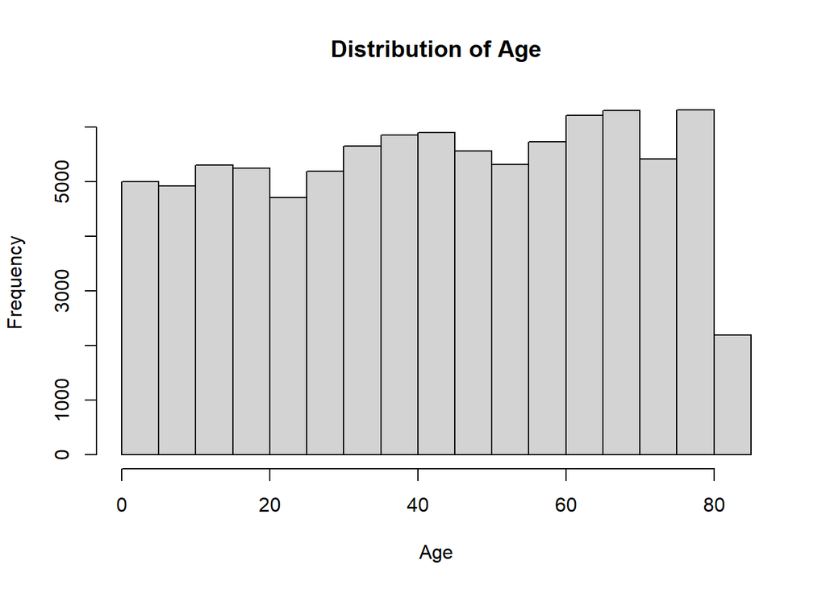

```r
# Plotting the distribution of age
hist(
  cps$age,
  main = "Distribution of Age",
  xlab = "Age"
)
```

## Age and Usual Weekly Work Hours

The following scatterplot examines the relationship between age and usual weekly work hours. Each point represents an observation with valid information for both variables.

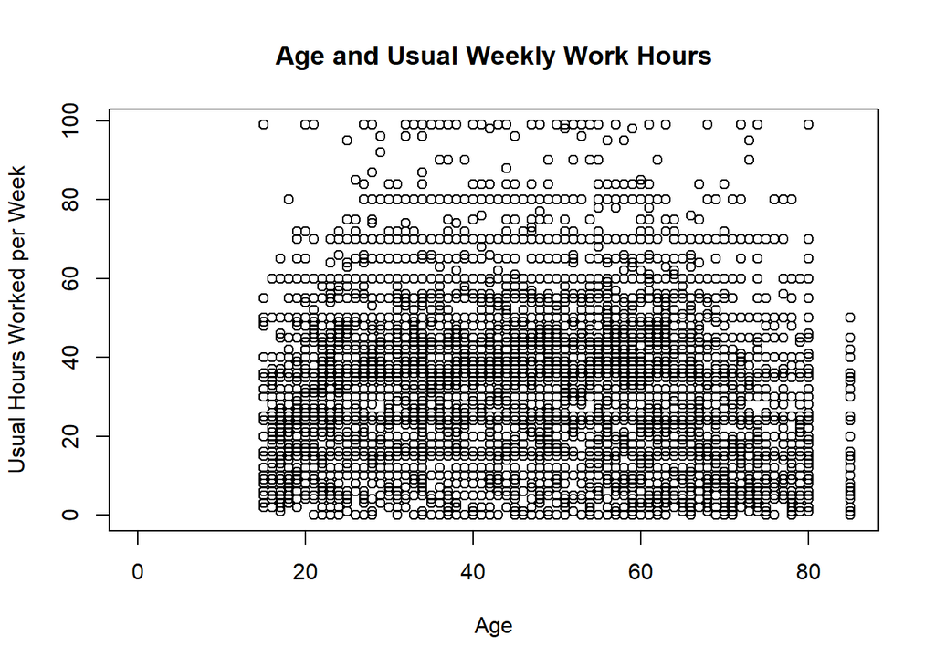

```r
# Plotting age and usual weekly work hours
plot(
  cps$age,
  cps$hours,
  main = "Age and Usual Weekly Work Hours",
  xlab = "Age",
  ylab = "Usual Hours Worked per Week"
)
```

## Conclusion

This assignment used July 2026 CPS data from IPUMS to practice importing, selecting, transforming, summarizing, and visualizing data in R. The analysis included both quantitative and categorical variables. Educational attainment, employment status, and sex were transformed into new variables, and age and usual weekly work hours were used for the quantitative analysis and visualizations.